# Análise de risco de crédito

O risco de crédito refere-se à possibilidade de um tomador de empréstimo não cumprir suas obrigações financeiras, como o pagamento de parcelas de um financiamento ou cartão de crédito. Esse risco é uma preocupação central para instituições financeiras, pois afeta diretamente sua rentabilidade, liquidez e estabilidade.

No contexto bancário, a análise de risco de crédito permite que bancos e outras instituições financeiras avaliem a probabilidade de inadimplência de um cliente e tomem decisões mais assertivas sobre concessão de crédito, taxas de juros e políticas de cobrança. Um modelo eficaz de previsão do risco de crédito pode ajudar a minimizar perdas financeiras, reduzir a inadimplência e tornar o processo de concessão de crédito mais eficiente e justo.

Do ponto de vista econômico, a gestão adequada do risco de crédito tem um impacto significativo na estabilidade do sistema financeiro. Crises econômicas, como a de 2008, demonstraram como uma avaliação inadequada do risco pode levar a colapsos financeiros. Por outro lado, um modelo bem estruturado possibilita a inclusão financeira de mais pessoas e empresas, fomentando o crescimento econômico ao facilitar o acesso ao crédito de forma responsável.

## Bibliotecas

```python
import pandas as pd
import matplotlib.pyplot as plt
import seaborn as sns
from sklearn.metrics import accuracy_score, confusion_matrix, classification_report
from sklearn.tree import DecisionTreeClassifier
from sklearn.linear_model import LogisticRegression
from sklearn.metrics import mean_absolute_error, mean_squared_error
from sklearn.preprocessing import LabelEncoder
from sklearn.model_selection import train_test_split
from sklearn.preprocessing import StandardScaler
import shap
import numpy as np

sns.set_theme(palette='Set2', style="whitegrid")
```

```python
df = pd.read_csv('credit_customers.csv')
```

```python
df.head()
```

|  | checking_status | duration | credit_history | purpose | credit_amount | savings_status | employment | installment_commitment | personal_status | other_parties | ... | property_magnitude | age | other_payment_plans | housing | existing_credits | job | num_dependents | own_telephone | foreign_worker | class |
| --- | --- | --- | --- | --- | --- | --- | --- | --- | --- | --- | --- | --- | --- | --- | --- | --- | --- | --- | --- | --- | --- |
| 0 | <0 | 6.0 | critical/other existing credit | radio/tv | 1169.0 | no known savings | >=7 | 4.0 | male single | none | ... | real estate | 67.0 | none | own | 2.0 | skilled | 1.0 | yes | yes | good |
| 1 | 0<=X<200 | 48.0 | existing paid | radio/tv | 5951.0 | <100 | 1<=X<4 | 2.0 | female div/dep/mar | none | ... | real estate | 22.0 | none | own | 1.0 | skilled | 1.0 | none | yes | bad |
| 2 | no checking | 12.0 | critical/other existing credit | education | 2096.0 | <100 | 4<=X<7 | 2.0 | male single | none | ... | real estate | 49.0 | none | own | 1.0 | unskilled resident | 2.0 | none | yes | good |
| 3 | <0 | 42.0 | existing paid | furniture/equipment | 7882.0 | <100 | 4<=X<7 | 2.0 | male single | guarantor | ... | life insurance | 45.0 | none | for free | 1.0 | skilled | 2.0 | none | yes | good |
| 4 | <0 | 24.0 | delayed previously | new car | 4870.0 | <100 | 1<=X<4 | 3.0 | male single | none | ... | no known property | 53.0 | none | for free | 2.0 | skilled | 2.0 | none | yes | bad |

5 rows × 21 columns

```python
df.describe()
```

|  | duration | credit_amount | installment_commitment | residence_since | age | existing_credits | num_dependents |
| --- | --- | --- | --- | --- | --- | --- | --- |
| count | 1000.000000 | 1000.000000 | 1000.000000 | 1000.000000 | 1000.000000 | 1000.000000 | 1000.000000 |
| mean | 20.903000 | 3271.258000 | 2.973000 | 2.845000 | 35.546000 | 1.407000 | 1.155000 |
| std | 12.058814 | 2822.736876 | 1.118715 | 1.103718 | 11.375469 | 0.577654 | 0.362086 |
| min | 4.000000 | 250.000000 | 1.000000 | 1.000000 | 19.000000 | 1.000000 | 1.000000 |
| 25% | 12.000000 | 1365.500000 | 2.000000 | 2.000000 | 27.000000 | 1.000000 | 1.000000 |
| 50% | 18.000000 | 2319.500000 | 3.000000 | 3.000000 | 33.000000 | 1.000000 | 1.000000 |
| 75% | 24.000000 | 3972.250000 | 4.000000 | 4.000000 | 42.000000 | 2.000000 | 1.000000 |
| max | 72.000000 | 18424.000000 | 4.000000 | 4.000000 | 75.000000 | 4.000000 | 2.000000 |

```python
print(df.info())
```

```
<class 'pandas.core.frame.DataFrame'>
RangeIndex: 1000 entries, 0 to 999
Data columns (total 21 columns):
 #   Column                  Non-Null Count  Dtype
---  ------                  --------------  -----
 0   checking_status         1000 non-null   object
 1   duration                1000 non-null   float64
 2   credit_history          1000 non-null   object
 3   purpose                 1000 non-null   object
 4   credit_amount           1000 non-null   float64
 5   savings_status          1000 non-null   object
 6   employment              1000 non-null   object
 7   installment_commitment  1000 non-null   float64
 8   personal_status         1000 non-null   object
 9   other_parties           1000 non-null   object
 10  residence_since         1000 non-null   float64
 11  property_magnitude      1000 non-null   object
 12  age                     1000 non-null   float64
 13  other_payment_plans     1000 non-null   object
 14  housing                 1000 non-null   object
 15  existing_credits        1000 non-null   float64
 16  job                     1000 non-null   object
 17  num_dependents          1000 non-null   float64
 18  own_telephone           1000 non-null   object
 19  foreign_worker          1000 non-null   object
 20  class                   1000 non-null   object
dtypes: float64(7), object(14)
memory usage: 164.2+ KB
None
```

## Análise dos dados

```python
df["class"].value_counts()
```

```
class
good    700
bad     300
Name: count, dtype: int64
```

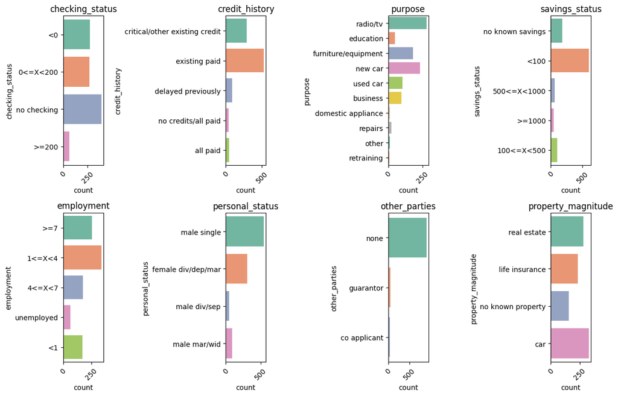

```python
variables = [
    'checking_status', 'credit_history', 'purpose', 'savings_status',
    'employment', 'personal_status',
    'other_parties', 'property_magnitude'
]


fig, axes = plt.subplots(nrows=2, ncols=4, figsize=(12, 8))

axes = axes.flatten()

for i, var in enumerate(variables):
    axes[i].set_title(var)
    sns.countplot(y=var, palette='Set2', data=df, ax=axes[i], hue=var)
    axes[i].tick_params(axis='x', rotation=45)

plt.tight_layout()
plt.show()
```

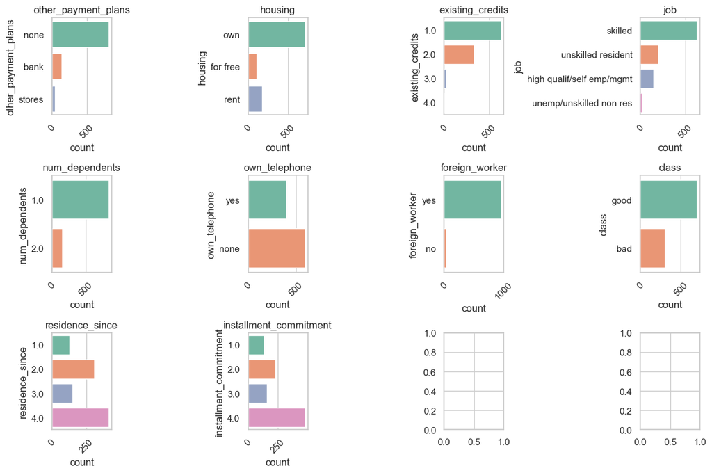

```python
variables = ['other_payment_plans', 'housing', 'existing_credits', 'job',
             'num_dependents', 'own_telephone', 'foreign_worker', 'class',
             'residence_since', 'installment_commitment']


fig, axes = plt.subplots(nrows=3, ncols=4, figsize=(12, 8))

axes = axes.flatten()

for i, var in enumerate(variables):
    axes[i].set_title(var)
    sns.countplot(y=var, palette='Set2', data=df, ax=axes[i], hue=var, legend=False)
    axes[i].tick_params(axis='x', rotation=45)

plt.tight_layout()
plt.show()
```

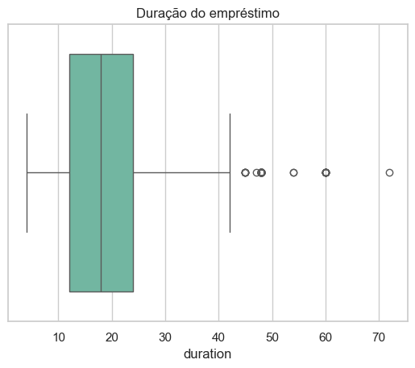

```python
plt.title("Duração do empréstimo")
sns.boxplot(x=df["duration"])

plt.show()
```

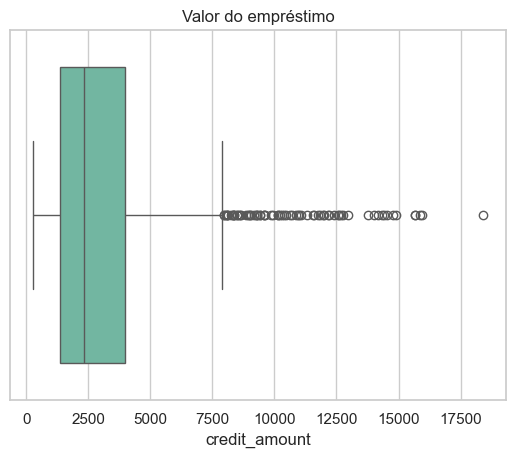

```python
plt.title("Valor do empréstimo")
sns.boxplot(x=df["credit_amount"])

plt.show()
```

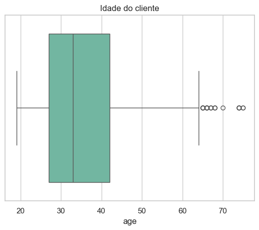

```python
plt.title("Idade do cliente")
sns.boxplot(x=df["age"])

plt.show()
```

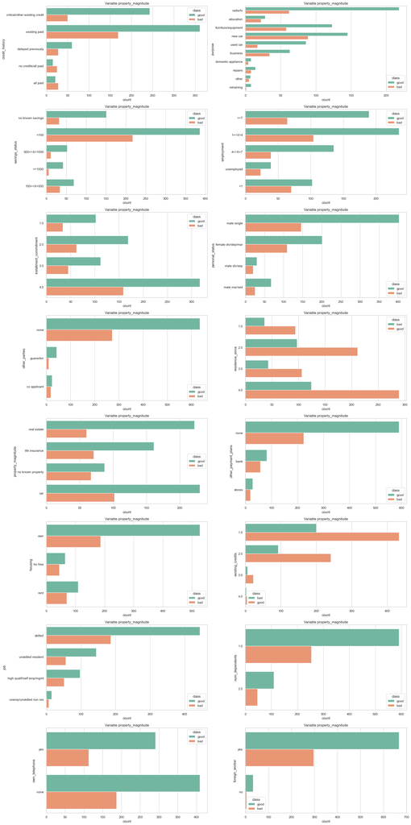

```python
fig, axes = plt.subplots(nrows=8, ncols=2, figsize=(20, 40))

variables = ['credit_history', 'purpose', 'savings_status', 'employment',
             'installment_commitment', 'personal_status', 'other_parties',
             'residence_since', 'property_magnitude', 'other_payment_plans',
             'housing', 'existing_credits', 'job', 'num_dependents',
             'own_telephone', 'foreign_worker']

axes = axes.flatten()

for i, var in enumerate(variables):
    axes[i].set_title(title)
    sns.countplot(y=var, hue='class', palette='Set2', data=df, ax=axes[i])

plt.tight_layout()
plt.show()
```

### Correlação

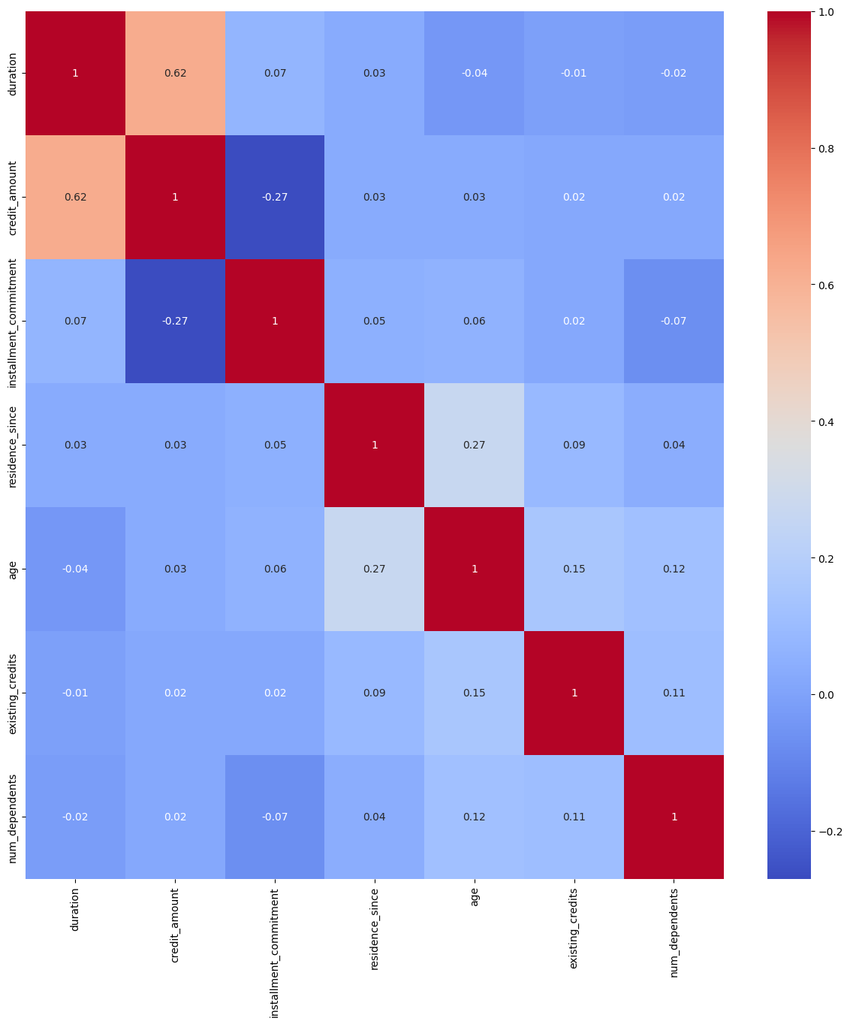

```python
corr = df.corr(numeric_only=True).round(2)
plt.figure(figsize = (15,15))
sns.heatmap(corr, annot = True, cmap = 'coolwarm')

plt.show()
```

### Pontos relevantes da análise

- Predomínio de clientes com propriedade própria e empregos qualificados:
- A maioria dos clientes possui suas casas, tem empregos qualificados e muitos são trabalhadores estrangeiros.
- Desbalanceamento da variável alvo: A variável alvo (clientes bons e ruins) está desbalanceada, com muito mais clientes bons do que ruins.
- A maioria das solicitações de crédito vem de pessoas na faixa dos 30 anos.
- Quanto mais velhas as pessoas, menor a quantidade de dados, o que também se reflete na variável credit_amount.

**Comportamento notável nas variáveis em comparação com a variável alvo:**

## Modelagem

### Features

```python
cat_features = [
    'checking_status', 'credit_history', 'purpose', 'savings_status',
    'employment', 'personal_status', 'other_parties', 'property_magnitude',
    'other_payment_plans', 'housing', 'job', 'own_telephone', 'foreign_worker'
]

num_features = [
    'duration', 'credit_amount', 'installment_commitment', 'residence_since',
    'age', 'existing_credits', 'num_dependents'
]
```

```python
one_hot = pd.get_dummies(df[cat_features], drop_first=True, dtype=int)
one_hot.head()
```

|  | checking_status_<0 | checking_status_>=200 | checking_status_no checking | credit_history_critical/other existing credit | credit_history_delayed previously | credit_history_existing paid | credit_history_no credits/all paid | purpose_domestic appliance | purpose_education | purpose_furniture/equipment | ... | property_magnitude_real estate | other_payment_plans_none | other_payment_plans_stores | housing_own | housing_rent | job_skilled | job_unemp/unskilled non res | job_unskilled resident | own_telephone_yes | foreign_worker_yes |
| --- | --- | --- | --- | --- | --- | --- | --- | --- | --- | --- | --- | --- | --- | --- | --- | --- | --- | --- | --- | --- | --- |
| 0 | 1 | 0 | 0 | 1 | 0 | 0 | 0 | 0 | 0 | 0 | ... | 1 | 1 | 0 | 1 | 0 | 1 | 0 | 0 | 1 | 1 |
| 1 | 0 | 0 | 0 | 0 | 0 | 1 | 0 | 0 | 0 | 0 | ... | 1 | 1 | 0 | 1 | 0 | 1 | 0 | 0 | 0 | 1 |
| 2 | 0 | 0 | 1 | 1 | 0 | 0 | 0 | 0 | 1 | 0 | ... | 1 | 1 | 0 | 1 | 0 | 0 | 0 | 1 | 0 | 1 |
| 3 | 1 | 0 | 0 | 0 | 0 | 1 | 0 | 0 | 0 | 1 | ... | 0 | 1 | 0 | 0 | 0 | 1 | 0 | 0 | 0 | 1 |
| 4 | 1 | 0 | 0 | 0 | 1 | 0 | 0 | 0 | 0 | 0 | ... | 0 | 1 | 0 | 0 | 0 | 1 | 0 | 0 | 0 | 1 |

5 rows × 41 columns

```python
df_to_train = pd.concat([df[num_features], one_hot], axis = 1)
```

```python
label_encoder_class = LabelEncoder()
df['class'] = label_encoder_class.fit_transform(df['class'])
```

```python
X = df_to_train
y = df['class']
```

```python
X_train, X_test, y_train, y_test = train_test_split(X, y, test_size = 0.2, random_state = 0, stratify=df['class'])
```

```python
scaler = StandardScaler()
X_train_scaled = scaler.fit_transform(X_train)
X_test_scaled = scaler.transform(X_test)
```

### Árvore de decisão

```python
dtc = DecisionTreeClassifier(random_state=42)
dtc.fit(X_train_scaled, y_train)
```

```
DecisionTreeClassifier(random_state=42)
```

```python
y_pred = dtc.predict(X_test_scaled)
```

```python
print(classification_report(y_test, y_pred))
```

```
              precision    recall  f1-score   support

           0       0.57      0.65      0.61        60
           1       0.84      0.79      0.82       140

    accuracy                           0.75       200
   macro avg       0.71      0.72      0.71       200
weighted avg       0.76      0.75      0.75       200
```

### Regressão Logística

```python
lr = LogisticRegression(max_iter=1000)
lr.fit(X_train_scaled, y_train)
```

```
LogisticRegression(max_iter=1000)
```

```python
y_pred = lr.predict(X_test_scaled)
```

```python
print(classification_report(y_test, y_pred))
```

```
              precision    recall  f1-score   support

           0       0.67      0.50      0.57        60
           1       0.81      0.89      0.85       140

    accuracy                           0.78       200
   macro avg       0.74      0.70      0.71       200
weighted avg       0.76      0.78      0.76       200
```

## SHAP

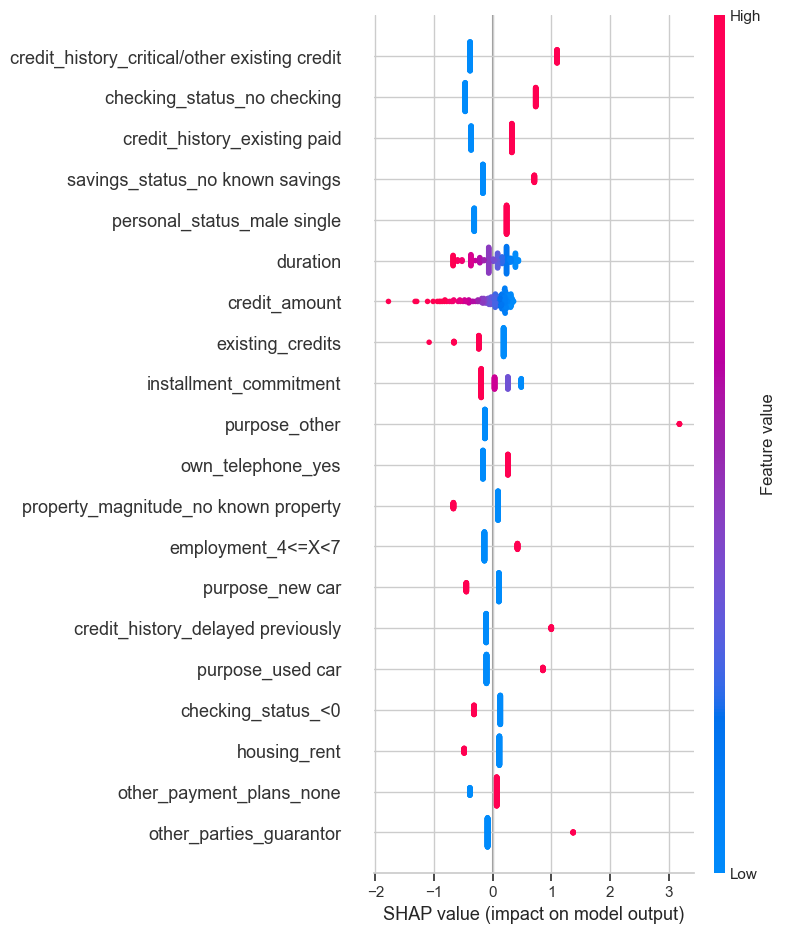

```python
explainer = shap.Explainer(lr, X_train_scaled)

shap_values = explainer(X_test_scaled)

shap.summary_plot(shap_values, X_test, feature_names=X_test.columns)
```

```python
shap_importance = pd.DataFrame({
    'Feature': X_train.columns,
    'Importance': np.abs(shap_values.values).mean(axis=0)
})

shap_importance = shap_importance.sort_values(by='Importance', ascending=False)

top_10_features = shap_importance.head(10)

print(top_10_features)
```

```
                                          Feature  Importance
10  credit_history_critical/other existing credit    0.609235
9                     checking_status_no checking    0.574093
12                   credit_history_existing paid    0.344881
26                savings_status_no known savings    0.275018
33                    personal_status_male single    0.271047
0                                        duration    0.255557
1                                   credit_amount    0.246645
5                                existing_credits    0.224906
2                          installment_commitment    0.217065
18                                  purpose_other    0.208725
```

### Análise dos valores SHAP e conclusões

A análise dos valores SHAP nos permite identificar as variáveis que mais influenciam a classificação dos clientes no modelo de regressão logística. Abaixo, estão as 10 variáveis mais importantes que impactam as previsões do modelo:

- **credit_history_critical/other existing credit**

- **checking_status_no checking**

- **credit_history_existing paid**

Importância: 0.344881 Interpretação Econômica: Clientes com um histórico de crédito bem pago geralmente têm maior capacidade de gestão financeira, o que reduz o risco de inadimplência. Eles têm mais probabilidade de cumprir com seus compromissos financeiros. Interpretação de Negócios: Ter um histórico de crédito pago é um indicativo de confiabilidade e capacidade de pagamento. Isso é vantajoso para o credor, pois esses clientes têm maior probabilidade de pagar suas dívidas.

- **savings_status_no known savings**

- **personal_status_male single**

- **duration**

Importância: 0.255557 Interpretação Econômica: O tempo de duração do empréstimo é uma variável crucial. Empréstimos com períodos mais longos podem aumentar o risco, pois a probabilidade de mudança nas condições financeiras do cliente é maior com o tempo. Interpretação de Negócios: Durações de empréstimos mais longas podem aumentar o risco de inadimplência, já que os clientes podem enfrentar dificuldades financeiras inesperadas durante esse período.

- **credit_amount**

Importância: 0.246645 Interpretação Econômica: O valor do crédito solicitado tem uma correlação direta com o risco de inadimplência. Quanto maior o valor do crédito, maior a responsabilidade do cliente em cumprir com os pagamentos, o que pode aumentar o risco. Interpretação de Negócios: A concessão de grandes valores de crédito pode aumentar a exposição ao risco. Limitar o valor do crédito pode ser uma estratégia para reduzir a inadimplência.

- **existing_credits**

Importância: 0.224906 Interpretação Econômica: O número de créditos existentes indica o grau de endividamento do cliente. Quanto mais créditos existentes, maior a chance de sobrecarga financeira e, portanto, maior o risco de inadimplência. Interpretação de Negócios: Clientes com múltiplos créditos podem ser mais propensos a falhar no pagamento, pois já possuem várias obrigações financeiras.

- **installment_commitment**

Importância: 0.217065 Interpretação Econômica: O valor do compromisso com parcelas pode indicar o quanto o cliente está comprometido com pagamentos mensais. Compromissos financeiros mais elevados podem aumentar a probabilidade de inadimplência, especialmente se o cliente tiver dificuldades financeiras. Interpretação de Negócios: É crucial monitorar o nível de endividamento dos clientes. Compromissos de parcelas elevadas podem indicar que o cliente tem uma maior probabilidade de não conseguir cumprir suas obrigações.

- **purpose_other**

## Tomada de Decisão

Com base nos resultados do modelo, algumas recomendações estratégicas para a gestão do risco de crédito são:

### Limitação do Valor de Crédito

Variáveis como credit_amount e existing_credits indicam que clientes com maiores solicitações de crédito ou múltiplos créditos existentes possuem maior risco. Limitar o valor de crédito ou exigir uma avaliação mais rigorosa para esses clientes pode reduzir o risco de inadimplência.

### Atenção à Duração do Empréstimo

A duração do empréstimo (duration) deve ser cuidadosamente avaliada. Empréstimos com prazos mais longos aumentam o risco de inadimplência. Oferecer opções de prazos mais curtos pode reduzir a exposição ao risco.

### Análise Detalhada de Clientes com Endividamento Alto

Para clientes com múltiplos créditos (existing_credits), uma análise detalhada deve ser feita. Essas pessoas podem ser mais vulneráveis a falhas no pagamento. Reavaliar esses clientes periodicamente e estabelecer limites de crédito mais restritos pode ajudar. Essas recomendações podem ajudar na criação de uma política de crédito mais segura e personalizada, levando em conta os principais fatores de risco identificados pelo modelo.